# Syntax Tugas Pertemuan 67

Ignacia Manuela Bregina

2023-16-02

## Packages

```r
library(ggplot2)
library(tsibble)
library(tseries)
library(MASS)
library(forecast)
library(TSA)
library(TTR)
library(aTSA)
library(graphics)
```

## Input Data

```r
library(rio)
data <- import("https://raw.githubusercontent.com/ignaciatarigan/MPDW/main/Pertemuan%2067/newdata.csv")
databaru <- data[,-1]
databaru
```

```
##     Period WS50M
## 1        1  5.58
## 2        2  4.59
## 3        3  3.05
## 4        4  2.95
## 5        5  3.56
## 6        6  3.94
## 7        7  9.41
## 8        8  5.88
## 9        9  6.23
## 10      10  3.70
## 11      11  4.92
## 12      12  2.99
## 13      13  3.38
## 14      14  4.52
```

[output cut: 351 more lines]

## Eksplorasi Data

Sebelum masuk dalam tahap pemodelan, dilakukan eksplorasi data dengan plot deret waktu untuk melihat pola data.

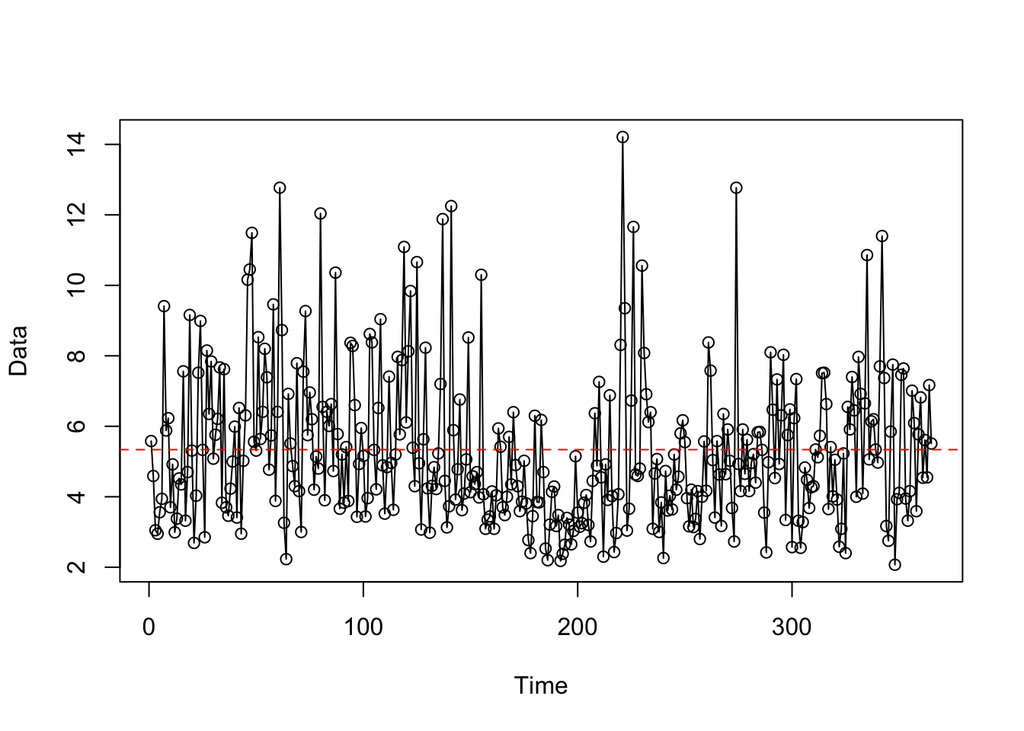

```r
#--PLOT TIME SERIES--#
plot(databaru,
     col = "black",
     lwd = 1,
     type = "o",
     xlab = "Time",
     ylab = "Data")
abline(h = mean(databaru$WS50M), col = "red", lty = 2)
```

```r
mean(databaru$WS50M)
```

```
## [1] 5.337589
```

Berdasarkan plot data deret waktu di atas, terlihat data cenderung **tidak stasioner dalam ragam**. Data stasioner dalam rataan karena menyebar/bergerak di sekitar nilai tengahnya dan dikatakan stasioner dalam ragam karena memiliki lebar pita yang cenderung sama. Sedangkan pada plot diatas terlihat bahwa data cukup menyebar/bergerak di sekitar nilai tengahnya yakni 5.337589 namun lebar pita menunjukkan cenderung jauh/berbeda. Selain dengan plot data deret waktu, akan dilakukan pengecekan stasioneritas data dengan plot ACF dan uji ADF.

## Data Time Series

Membuat data time series dari data awal

```r
databaru.ts <- ts(databaru$WS50M)
```

Data kemudian dibagi menjadi data latih dan data uji.

```r
databaru.train <- databaru.ts[1:292]
databaru.test <- databaru.ts[293:365]
databaru.train<- ts(databaru.train)
databaru.test <- ts(databaru.test)
```

### Plot ACF

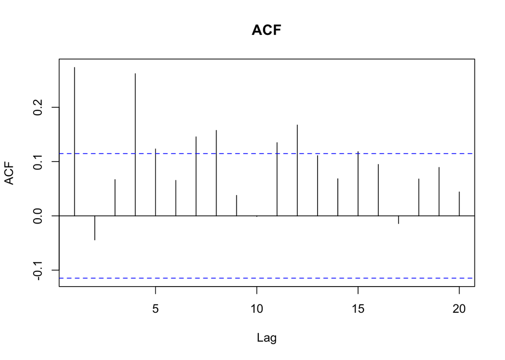

```r
acf(databaru.train, main="ACF", lag.max=20)
```

Berdasarkan plot ACF, terlihat bahwa plot ACF pada data tersebut cenderung *tails off* dan membentuk gelombang sinus.

### ADF

```r
tseries::adf.test(databaru.train, k = 6)
```

```
##
##  Augmented Dickey-Fuller Test
##
## data:  databaru.train
## Dickey-Fuller = -4.5224, Lag order = 6, p-value = 0.01
## alternative hypothesis: stationary
```

$H_0$ : Data tidak stasioner dalam rataan

$H_1$ : Data stasioner dalam rataan

Berdasarkan uji ADF tersebut, didapat *p-value* sebesar 0.01 yang lebih kecil dari taraf nyata 5% sehingga tolak $H_0$ dan menandakan bahwa data memang stasioner dalam rataan. Hal ini sesuai dengan hasil eksplorasi menggunakan plot time series dan plot ACF.

### Boxcox

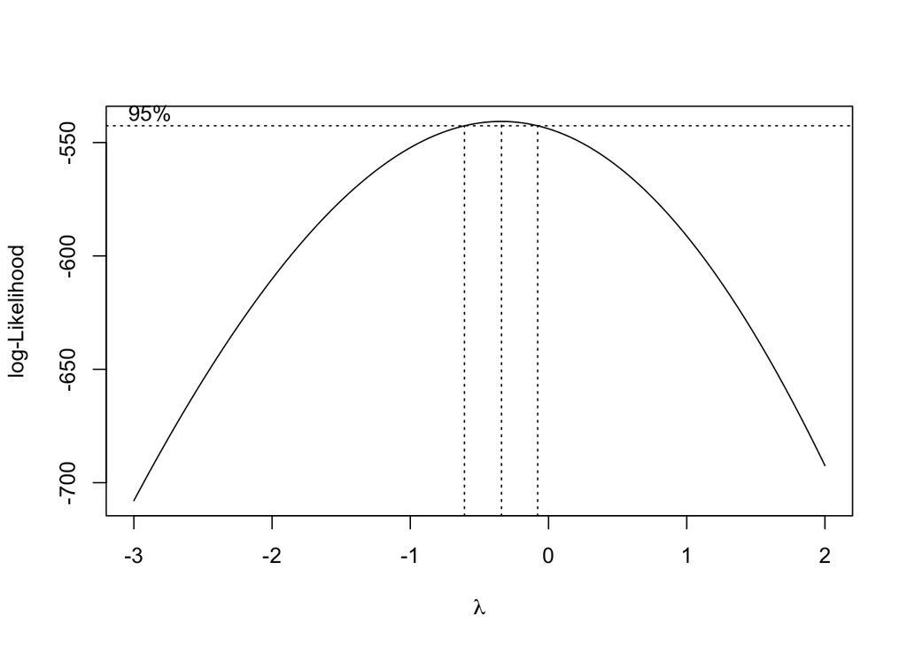

```r
index <- seq(1:292) #sebanyak row data
bc = boxcox(databaru.train~index, lambda = seq(-3,2,by=0.01))
```

```r
#Nilai Rounded Lambda
lambda <- bc$x[which.max(bc$y)]
lambda
```

```
## [1] -0.34
```

```r
#SK
bc$x[bc$y > max(bc$y) - 1/2 * qchisq(.95,1)]
```

```
##  [1] -0.60 -0.59 -0.58 -0.57 -0.56 -0.55 -0.54 -0.53 -0.52 -0.51 -0.50 -0.49
## [13] -0.48 -0.47 -0.46 -0.45 -0.44 -0.43 -0.42 -0.41 -0.40 -0.39 -0.38 -0.37
## [25] -0.36 -0.35 -0.34 -0.33 -0.32 -0.31 -0.30 -0.29 -0.28 -0.27 -0.26 -0.25
## [37] -0.24 -0.23 -0.22 -0.21 -0.20 -0.19 -0.18 -0.17 -0.16 -0.15 -0.14 -0.13
## [49] -0.12 -0.11 -0.10 -0.09 -0.08
```

Plot Boxcox menunjukkan nilai *rounded value* ($\lambda$) optimum sebesar **-0.34** dan pada selang kepercayaan 95% nilai memiliki batas bawah **-0.60** dan batas atas **-0.08**. Selang tersebut tidak memuat nilai satu sehingga dapat dikatakan bahwa data yang digunakan tidak stasioner dalam ragam.

# Data hanya tidak stasioner dalam ragam maka langsung lanjut ke pemodelan

## Identifikasi Model

### Plot ACF

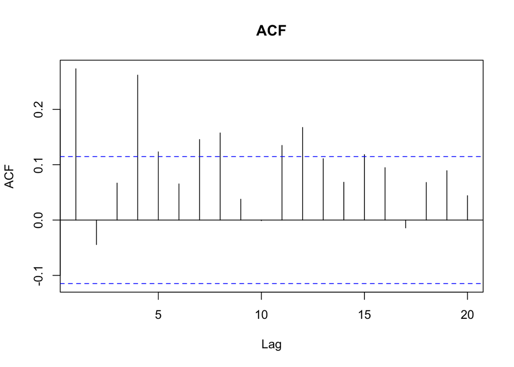

```r
acf(databaru.train, main="ACF", lag.max=20)
```

### Plot PACF

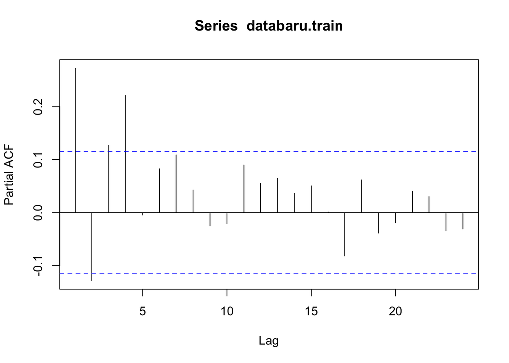

```r
pacf(databaru.train)
```

### Plot EACF

```r
eacf(databaru.train)
```

```
## AR/MA
##   0 1 2 3 4 5 6 7 8 9 10 11 12 13
## 0 x o o x x o x x o o x  x  o  o
## 1 x o o x o o o x o o o  o  o  o
## 2 x o o x o o o x o o o  o  o  o
## 3 x x x o o o o o o o o  o  o  o
## 4 o x x o o o o o o o o  o  o  o
## 5 o x x o x o o o o o o  o  o  o
## 6 x x o o o o o o o o o  o  o  o
## 7 x x x o x o x o o o o  o  o  o
```

Identifikasi model menggunakan plot EACF dilakukan dengan melihat ujung segitiga pada pola segitiga nol. Dalam hal ini model tentatif yang terbentuk adalah ARIMA(0,0,1), ARIMA(1,0,2), (2,0,4), dan (3,0,3).

## Pendugaan Parameter Model Tentatif

### ARIMA(1,0,1)

```r
model1.da=Arima(databaru.train, order=c(1,0,1),method="ML")
summary(model1.da)
```

```
## Series: databaru.train
## ARIMA(1,0,1) with non-zero mean
##
## Coefficients:
##           ar1     ma1    mean
##       -0.0416  0.3564  5.3149
## s.e.   0.1394  0.1249  0.1609
##
## sigma^2 = 4.511:  log likelihood = -632.82
## AIC=1273.64   AICc=1273.78   BIC=1288.34
##
## Training set error measures:
##                         ME     RMSE      MAE       MPE     MAPE      MASE
## Training set -1.672912e-05 2.112905 1.620568 -13.96551 32.80017 0.8016476
##                      ACF1
## Training set -0.000227047
```

```r
lmtest::coeftest(model1.da)
```

```
##
## z test of coefficients:
##
##            Estimate Std. Error z value  Pr(>|z|)
## ar1       -0.041571   0.139351 -0.2983  0.765459
## ma1        0.356431   0.124890  2.8540  0.004318 **
## intercept  5.314901   0.160904 33.0315 < 2.2e-16 ***
## ---
## Signif. codes:  0 '***' 0.001 '**' 0.01 '*' 0.05 '.' 0.1 ' ' 1
```

AIC=1273.64 Peubah Tidak Signifikan

### ARIMA(0,0,1)

```r
model2.da=Arima(databaru.train, order=c(0,0,1),method="ML")
summary(model2.da)
```

```
## Series: databaru.train
## ARIMA(0,0,1) with non-zero mean
##
## Coefficients:
##          ma1    mean
##       0.3220  5.3154
## s.e.  0.0543  0.1634
##
## sigma^2 = 4.496:  log likelihood = -632.86
## AIC=1271.73   AICc=1271.81   BIC=1282.76
##
## Training set error measures:
##                         ME     RMSE      MAE       MPE     MAPE      MASE
## Training set -0.0004224296 2.113221 1.621308 -13.93594 32.79426 0.8020139
##                     ACF1
## Training set -0.00630013
```

```r
lmtest::coeftest(model2.da)
```

```
##
## z test of coefficients:
##
##           Estimate Std. Error z value  Pr(>|z|)
## ma1        0.32204    0.05432  5.9285 3.057e-09 ***
## intercept  5.31535    0.16336 32.5384 < 2.2e-16 ***
## ---
## Signif. codes:  0 '***' 0.001 '**' 0.01 '*' 0.05 '.' 0.1 ' ' 1
```

AIC=1271.73 Peubah Signifikan

### ARIMA(1,0,2)

```r
model3.da=Arima(databaru.train, order=c(1,0,2),method="ML")
summary(model3.da)
```

```
## Series: databaru.train
## ARIMA(1,0,2) with non-zero mean
##
## Coefficients:
##          ar1     ma1      ma2    mean
##       0.1378  0.1740  -0.0650  5.3152
## s.e.  0.5427  0.5387   0.1742  0.1589
##
## sigma^2 = 4.525:  log likelihood = -632.77
## AIC=1275.55   AICc=1275.76   BIC=1293.93
##
## Training set error measures:
##                         ME     RMSE     MAE       MPE     MAPE      MASE
## Training set -0.0002067826 2.112584 1.62083 -13.98363 32.81699 0.8017771
##                     ACF1
## Training set 0.003059641
```

```r
lmtest::coeftest(model3.da)
```

```
##
## z test of coefficients:
##
##            Estimate Std. Error z value Pr(>|z|)
## ar1        0.137804   0.542694  0.2539   0.7996
## ma1        0.174025   0.538705  0.3230   0.7467
## ma2       -0.064959   0.174198 -0.3729   0.7092
## intercept  5.315167   0.158920 33.4456   <2e-16 ***
## ---
## Signif. codes:  0 '***' 0.001 '**' 0.01 '*' 0.05 '.' 0.1 ' ' 1
```

AIC=1275.55 Peubah Tidak Signifikan

### ARIMA(2,0,4)

```r
model4.da=Arima(databaru.train, order=c(2,0,4),method="ML")
summary(model4.da)
```

```
## Series: databaru.train
## ARIMA(2,0,4) with non-zero mean
##
## Coefficients:
##          ar1     ar2      ma1      ma2      ma3     ma4    mean
##       0.5856  0.3206  -0.3006  -0.5541  -0.1081  0.2126  5.2897
## s.e.  0.2367  0.2298   0.2293   0.1703   0.0825  0.0549  0.3076
##
## sigma^2 = 4.235:  log likelihood = -621.76
## AIC=1259.52   AICc=1260.03   BIC=1288.94
##
## Training set error measures:
##                      ME     RMSE      MAE       MPE     MAPE      MASE
## Training set 0.01176945 2.033145 1.537181 -12.48004 30.66279 0.7603984
##                      ACF1
## Training set -0.004062779
```

```r
lmtest::coeftest(model4.da)
```

```
##
## z test of coefficients:
##
##            Estimate Std. Error z value  Pr(>|z|)
## ar1        0.585561   0.236662  2.4742 0.0133517 *
## ar2        0.320626   0.229839  1.3950 0.1630163
## ma1       -0.300621   0.229322 -1.3109 0.1898885
## ma2       -0.554103   0.170324 -3.2532 0.0011410 **
## ma3       -0.108056   0.082512 -1.3096 0.1903380
## ma4        0.212607   0.054927  3.8707 0.0001085 ***
## intercept  5.289738   0.307561 17.1990 < 2.2e-16 ***
## ---
## Signif. codes:  0 '***' 0.001 '**' 0.01 '*' 0.05 '.' 0.1 ' ' 1
```

AIC=1259.52 Peubah Tidak Signifikan

### ARIMA(3,0,3)

```r
model5.da=Arima(databaru.train, order=c(3,0,3),method="ML")
summary(model5.da)
```

```
## Series: databaru.train
## ARIMA(3,0,3) with non-zero mean
##
## Coefficients:
##          ar1      ar2     ar3      ma1     ma2      ma3    mean
##       0.7850  -0.5294  0.6555  -0.5107  0.2450  -0.4773  5.2906
## s.e.  0.1242   0.1726  0.1257   0.1400  0.1891   0.1345  0.3279
##
## sigma^2 = 4.187:  log likelihood = -620.11
## AIC=1256.22   AICc=1256.73   BIC=1285.63
##
## Training set error measures:
##                     ME     RMSE      MAE       MPE     MAPE      MASE
## Training set 0.0116148 2.021437 1.510328 -12.23736 30.03778 0.7471153
##                     ACF1
## Training set 0.003853821
```

```r
lmtest::coeftest(model5.da)
```

```
##
## z test of coefficients:
##
##           Estimate Std. Error z value  Pr(>|z|)
## ar1        0.78503    0.12423  6.3190 2.633e-10 ***
## ar2       -0.52941    0.17255 -3.0682 0.0021539 **
## ar3        0.65550    0.12569  5.2151 1.838e-07 ***
## ma1       -0.51065    0.14000 -3.6476 0.0002648 ***
## ma2        0.24495    0.18907  1.2956 0.1951263
## ma3       -0.47728    0.13451 -3.5482 0.0003878 ***
## intercept  5.29056    0.32794 16.1326 < 2.2e-16 ***
## ---
## Signif. codes:  0 '***' 0.001 '**' 0.01 '*' 0.05 '.' 0.1 ' ' 1
```

AIC=1256.22 Peubah Tidak Signifikan

## Analisis Sisaan

Model terbaik hasil identifikasi kemudian dicek asumsi sisaannya. Sisaan model ARIMA harus memenuhi asumsi normalitas, kebebasan sisaan, dan kehomogenan ragam. Diagnostik model dilakukan secara eksplorasi dan uji formal.

#### Eksplorasi Sisaan ARIMA (0,0,1)

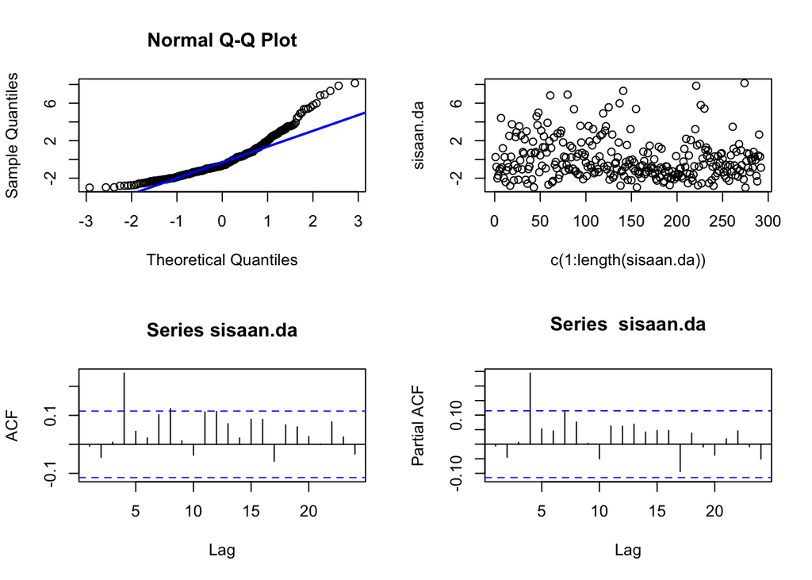

```r
#Eksplorasi
sisaan.da <- model2.da$residuals
par(mfrow=c(2,2))
qqnorm(sisaan.da)
qqline(sisaan.da, col = "blue", lwd = 2)
plot(c(1:length(sisaan.da)),sisaan.da)
acf(sisaan.da)
pacf(sisaan.da)
```

```r
par(mfrow = c(1,1))
```

## Uji Formal

### 1. Sisaan Menyebar Normal

```r
ks.test(sisaan.da,"pnorm")  #tak tolak H0 > sisaan menyebar normal
```

```
##
##  Asymptotic one-sample Kolmogorov-Smirnov test
##
## data:  sisaan.da
## D = 0.25145, p-value = 2.22e-16
## alternative hypothesis: two-sided
```

Selain dengan eksplorasi, asumsi tersebut dapat diuji menggunakan uji formal. Pada tahapan ini uji formal yang digunakan untuk normalitas adalah uji Kolmogorov-Smirnov (KS). Hipotesis pada uji KS adalah sebagai berikut.

$H_0$ : Sisaan menyebar normal

$H_1$ : Sisaan tidak menyebar normal

Berdasarkan uji KS tersebut, didapat *p-value* sebesar < 2.22e-16 yang kurang dari taraf nyata 5% sehingga tolak $H_0$ dan menandakan bahwa sisaan tidak menyebar normal. Hal ini sesuai dengan hasil eksplorasi menggunakan plot kuantil-kuantil normal.

### 2. Sisaan Saling bebas/tidak ada autokorelasi

```r
Box.test(sisaan.da, type = "Ljung")  #tak tolak H0 > sisaan saling bebas
```

```
##
##  Box-Ljung test
##
## data:  sisaan.da
## X-squared = 0.011709, df = 1, p-value = 0.9138
```

Selanjutnya akan dilakukan uji formal untuk kebebasan sisaan menggunakan uji Ljung-Box. Hipotesis yang digunakan adalah sebagai berikut.

$H_0$ : Sisaan saling bebas

$H_1$ : Sisaan tidak tidak saling bebas

### 3. Sisaan homogen

```r
Box.test((sisaan.da)^2, type = "Ljung")  #tak tolak H0 > sisaan homogen
```

```
##
##  Box-Ljung test
##
## data:  (sisaan.da)^2
## X-squared = 0.10739, df = 1, p-value = 0.7431
```

Hipotesis yang digunakan untuk uji kehomogenan ragam adalah sebagai berikut.

$H_0$ : Ragam sisaan homogen

$H_1$ : Ragam sisaan tidak homogen

### 4. Nilai tengah sisaan sama dengan nol

```r
t.test(sisaan.da, mu = 0, conf.level = 0.95)  #tak tolak h0 > nilai tengah sisaan sama dengan 0
```

```
##
##  One Sample t-test
##
## data:  sisaan.da
## t = -0.00341, df = 291, p-value = 0.9973
## alternative hypothesis: true mean is not equal to 0
## 95 percent confidence interval:
##  -0.2442352  0.2433903
## sample estimates:
##     mean of x
## -0.0004224296
```

Terakhir, dengan uji-t, akan dicek apakah nilai tengah sisaan sama dengan nol. Hipotesis yang diujikan sebagai berikut.

$H_0$ : nilai tengah sisaan sama dengan 0

$H_1$ : nilai tengah sisaan tidak sama dengan 0

Berdasarkan uji-ttersebut, didapat *p-value* sebesar 0.9973 yang lebih besar dari taraf nyata 5% sehingga tak tolak $H_0$ dan menandakan bahwa nilai tengah sisaan sama dengan nol. Hal ini berbeda dengan eksplorasi.

## Peramalan

Peramalan dilakukan menggunakan fungsi `forecast()` . Contoh peramalan berikut ini dilakukan untuk 30 tahun ke depan.

```r
#---FORECAST---#
ramalan.da <- forecast::forecast(model1.da, h = 30)
ramalan.da
```

```
##     Point Forecast    Lo 80    Hi 80     Lo 95    Hi 95
## 293       5.042758 2.320943 7.764572 0.8801018 9.205414
## 294       5.326214 2.472671 8.179757 0.9620970 9.690332
## 295       5.314431 2.460665 8.168196 0.9499733 9.678888
## 296       5.314921 2.461155 8.168686 0.9504626 9.679379
## 297       5.314900 2.461135 8.168666 0.9504422 9.679358
## 298       5.314901 2.461135 8.168667 0.9504431 9.679359
## 299       5.314901 2.461135 8.168667 0.9504430 9.679359
## 300       5.314901 2.461135 8.168667 0.9504430 9.679359
## 301       5.314901 2.461135 8.168667 0.9504430 9.679359
## 302       5.314901 2.461135 8.168667 0.9504430 9.679359
## 303       5.314901 2.461135 8.168667 0.9504430 9.679359
## 304       5.314901 2.461135 8.168667 0.9504430 9.679359
## 305       5.314901 2.461135 8.168667 0.9504430 9.679359
## 306       5.314901 2.461135 8.168667 0.9504430 9.679359
```

[output cut: 16 more lines]

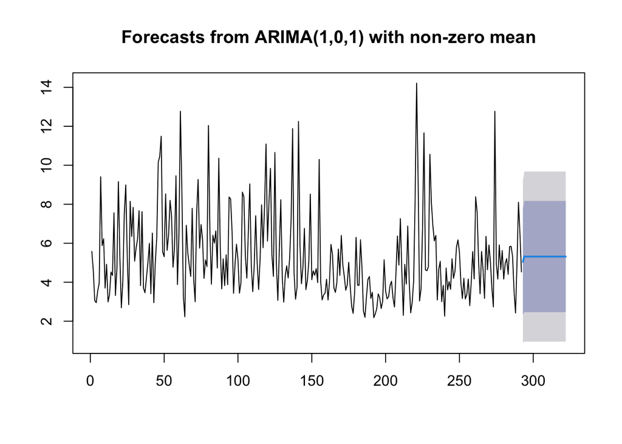

```r
data.ramalan.da <- ramalan.da$mean
plot(ramalan.da)
```

## Accuracy

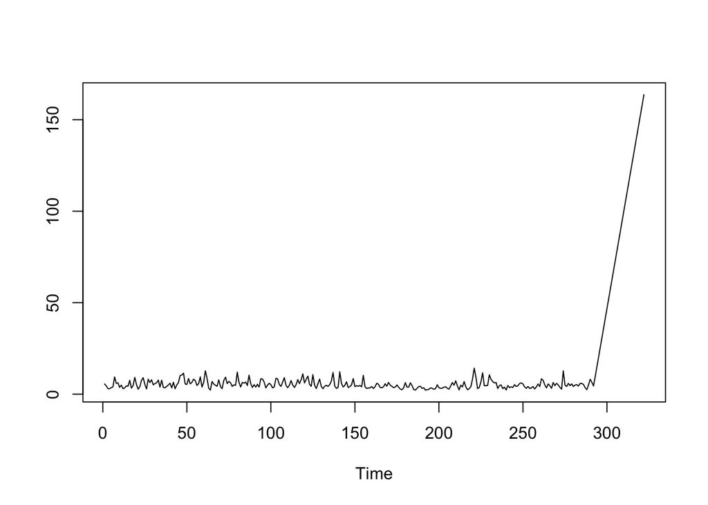

```r
pt_1 <- databaru.train[292] #nilai akhir data
hasil.forc.Diff <- data.ramalan.da
hasil <- diffinv(hasil.forc.Diff, differences = 1) + pt_1
#has.1 sama hasilnta dengan: cumsum(c(pt_1,hasil.forc.Diff))

ts.plot(databaru.train,hasil)
```

```r
perbandingan.da<-matrix(data=c(head(databaru.train, n=30), hasil[-1]),
                     nrow = 30, ncol = 2)
colnames(perbandingan.da)<-c("Aktual","Hasil Forecast")
perbandingan.da
```

```
##       Aktual Hasil Forecast
##  [1,]   5.58       9.572758
##  [2,]   4.59      14.898972
##  [3,]   3.05      20.213403
##  [4,]   2.95      25.528324
##  [5,]   3.56      30.843224
##  [6,]   3.94      36.158125
##  [7,]   9.41      41.473026
##  [8,]   5.88      46.787928
##  [9,]   6.23      52.102829
## [10,]   3.70      57.417730
## [11,]   4.92      62.732631
## [12,]   2.99      68.047532
## [13,]   3.38      73.362433
## [14,]   4.52      78.677335
```

[output cut: 16 more lines]

```r
accuracy(ts(hasil[-1]), head(databaru.train, n=30))
```

```
##                 ME     RMSE      MAE       MPE     MAPE      ACF1 Theil's U
## Test set -81.38501 93.20725 81.38501 -1690.577 1690.577 0.8951105  34.40476
```

```r
accuracy(ts(hasil[-1]), head(databaru.test, n=30))
```

```
##                 ME     RMSE      MAE       MPE     MAPE      ACF1 Theil's U
## Test set -81.59967 93.84929 81.59967 -1863.287 1863.287 0.8944824  49.71147
```